# Assignment 2 Task 2 - Parameter Estimation with Purrr - Lizards Length to Weight

Katherine Rosencrance

2023-02-14

# Overview

This report explores parameters of a length to weight model for lizard populations in New Mexico. Data were collected from 1989-2006 using pitfall traps at Jornada Basin LTER. Variables measured include species, sex, recapture status, snout-vent length, total length, weight, and whether tail is broken or whole (Lightfoot et al., 2020). This analysis will compare nonlinear least squares models for all lizard species and a subset of male Western Whiptail lizard (*Cnemidophorus tigrisatus*).

# Setup

```r
knitr::opts_chunk$set(echo = TRUE, warning = FALSE, message = FALSE)

# Attach packages
library(tidyverse)
library(here)
library(kableExtra)
library(Metrics)
```

```r
# Read in the data
lizards <- read_csv(here("data", "lizards.csv"))
```

# All Species NLS

$$\begin{equation}
\hat{W}=a(SVL)^b
\end{equation}$$

### Step one: Select Model (already done for us)

```r
# create a function in R using given model
func1 <- function(a,b,length){
 out= a*(length^b)
return(out)
}
```

### Step two: Initial Guess (by running standard OLS)

```r
# run OLS regression on log transformed data
my_guess_model <- lm(log(lizards$weight) ~ log(lizards$SV_length), data = lizards)

# get coefficients
coefficients(my_guess_model)
```

```
##            (Intercept) log(lizards$SV_length)
##              -8.256862               2.479417
```

```r
# (Intercept) log(lizards$SV_length)
#  -8.256862               2.479417

# mathematically transform the intercept coefficient to get the guess for parameter a
b <- my_guess_model$coefficients[2]
a <- exp((my_guess_model$coefficients[1]))
```

### Step three: Run NLS

```r
lizard_nls <- nls(weight~func1(a,b,SV_length),
                  data=lizards,
                  start=list(a = a, b=b),
                  trace=TRUE)
```

```
## 6388.704    (6.45e-01): par = (0.0002594719 2.479417)
## 6207.894    (6.12e-01): par = (0.0001925757 2.549348)
## 6013.160    (5.75e-01): par = (0.0001257406 2.649492)
## 4532.662    (4.95e-02): par = (0.0001004089 2.733743)
## 4521.994    (8.98e-03): par = (0.0001073039 2.720489)
## 4521.630    (1.93e-05): par = (0.0001073018 2.721001)
## 4521.630    (4.19e-07): par = (0.000107308 2.720987)
```

```r
#summary(lizard_nls)
broom::tidy(lizard_nls) %>%
  kable(caption = "Table 1: Original NLS Results") %>%
  kable_classic()
```

Table 1: Original NLS Results

| term | estimate | std.error | statistic | p.value |
| --- | --- | --- | --- | --- |
| a | 0.0001073 | 0.0000091 | 11.77374 | 0 |
| b | 2.7209866 | 0.0196796 | 138.26425 | 0 |

# Make a Prediction

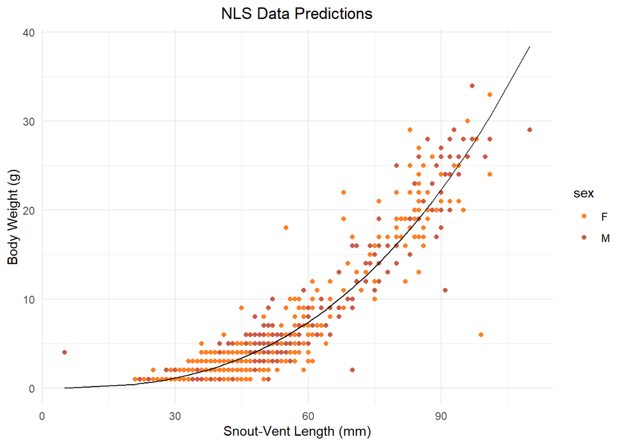

```r
# Make a prediction based on the model

lizard_predict<-lizards %>%
  mutate(predict=predict(lizard_nls,newdata=.))

ggplot(data=lizard_predict)+
  geom_point(aes(x= SV_length,y= weight, color = sex))+
  labs(x = "Snout-Vent Length (mm)",
      y = "Body Weight (g)",
      title = "NLS Data Predictions")+
  geom_line(aes(x=SV_length,y=predict), color='black') +
  scale_color_manual(values= c("chocolate1", "coral3"))+
  theme_minimal()+
  theme(plot.title = element_text(hjust = 0.5))
```

**Figure 1: NLS Data Prediction** Snout-vent length (mm) and body weight (g) for male and female lizards sampled from Jornada Basin LTER site. The red color represents males and the females are orange. The black line shows the predicted data using non-linear least squares to estimate parameters.

# Western Whiptail lizard NLS (*Cnemidophorus tigrisatus*)

```r
whip_lizard <- lizards %>%
  filter(spp == "CNTI", sex == "M")
```

### Step one: Select model (already done for us)

```r
# create a function in R using given model
func1 <- function(a,b,length){
 out= a*(length^b)
return(out)
}
```

### Step two: Initial Guess (by running standard OLS)

```r
# run OLS regression on log transformed data
my_guess_model_whip <- lm(log(whip_lizard$weight) ~ log(whip_lizard$SV_length), data = whip_lizard)

# get coefficients
coefficients(my_guess_model_whip)
```

```
##                (Intercept) log(whip_lizard$SV_length)
##                  -9.023963                   2.698108
```

```r
# (Intercept) log(lizards$SV_length)
#  -9.023963             2.698108

# mathematically transform the intercept coefficient to get the guess for parameter a
b_whip <- my_guess_model_whip$coefficients[2]
a_whip <- exp((my_guess_model_whip$coefficients[1]))
```

### Step three: Run NLS

```r
whip_lizard_nls <- nls(weight~func1(a,b,SV_length),
                  data=whip_lizard,
                  start=list(a = a_whip, b=b_whip),
                  trace=TRUE)
```

```
## 849.1572    (2.38e-01): par = (0.0001204877 2.698108)
## 845.6613    (2.27e-01): par = (0.0001330208 2.674996)
## 843.4176    (2.19e-01): par = (0.000145976 2.653427)
## 841.8629    (2.14e-01): par = (0.0001592699 2.633319)
## 840.6339    (2.09e-01): par = (0.0001728179 2.614592)
## 839.5079    (2.05e-01): par = (0.0001865362 2.597165)
## 838.3596    (2.00e-01): par = (0.0002003434 2.580958)
## 837.1280    (1.96e-01): par = (0.0002141623 2.565892)
## 835.7939    (1.91e-01): par = (0.0002279206 2.551894)
## 834.3628    (1.85e-01): par = (0.0002415522 2.538892)
## 832.8544    (1.80e-01): par = (0.0002549974 2.526816)
## 831.2942    (1.74e-01): par = (0.0002682034 2.515604)
## 830.9229    (1.72e-01): par = (0.0002940453 2.494784)
## 829.4807    (1.66e-01): par = (0.0003185494 2.476905)
## 827.3386    (1.57e-01): par = (0.0003414678 2.461569)
## 826.9172    (1.55e-01): par = (0.0003838388 2.435273)
## 822.7939    (1.37e-01): par = (0.0004187718 2.416406)
## 818.0644    (1.14e-01): par = (0.0004743038 2.389404)
## 809.0350    (4.10e-02): par = (0.0005336901 2.365838)
## 807.6757    (1.94e-04): par = (0.0005309859 2.368548)
## 807.6756    (1.74e-05): par = (0.0005316264 2.368276)
## 807.6756    (1.55e-06): par = (0.0005315663 2.368301)
```

```r
#summary(whip_lizard_nls)
broom::tidy(whip_lizard_nls) %>%
  kable(caption = "Table 2: NLS Results for Male Western Whiptail Lizard Subset") %>%
  kable_classic()
```

Table 2: NLS Results for Male Western Whiptail Lizard Subset

| term | estimate | std.error | statistic | p.value |
| --- | --- | --- | --- | --- |
| a | 0.0005316 | 0.0004288 | 1.239686 | 0.2192313 |
| b | 2.3683013 | 0.1800348 | 13.154689 | 0.0000000 |

# Make a prediction based on the model

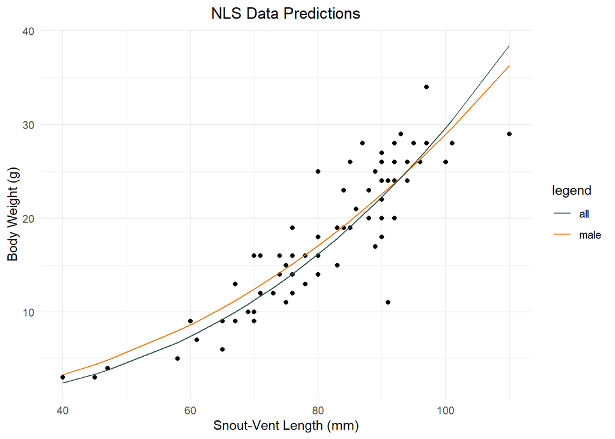

```r
# prediction for whiptail model
whip_lizard_predict<-whip_lizard %>%
  mutate(predict=predict(whip_lizard_nls,newdata=.)) %>%

# prediction for lizard model on whiptail dataset
  mutate(predict_with_orignls = predict(lizard_nls, newdata=.))

# plot both predictions on graph together
ggplot(data=whip_lizard_predict)+
  geom_point(aes(x= SV_length,y= weight))+
  labs(x = "Snout-Vent Length (mm)",
      y = "Body Weight (g)",
      title = "NLS Data Predictions")+
    geom_line(aes(x = SV_length,y = predict, color="male")) +
  geom_line(aes(x = SV_length, y = predict_with_orignls, color="all")) +
  scale_colour_manual(name= "legend",values=c("male"="darkorange2","all"= "darkslategray")) +
  theme_minimal()+
  theme(plot.title = element_text(hjust = 0.5))
```

```r
# calculate RMSE for both models
#function for RMSE

rmselizard <- rmse(whip_lizard_predict$weight, whip_lizard_predict$predict_with_orignls)

rmsewhiplizard <- rmse(whip_lizard_predict$weight, whip_lizard_predict$predict)
```

**Figure 1: Western Whiptail Lizard NLS Model vs. All Species NLS model** Snout-vent length (mm) and body weight (g) for male western whiptail lizards sampled from Jornada Basin LTER site. The orange line represents the NLS predictions for just the specific species of males and the black line shows the predicted data using NLS for all species and sexes. The RMSE for the species specific male NLS model is 3.34929 and the RMSE for the all species model is 3.46206. Because it has a lower root-mean square error, the model with just male whiptail lizards should be used to predict this specific data.

# Citation

**Data Citation:** Lightfoot, D. and W.G. Whitford. 2020. Lizard pitfall trap data from 11 NPP study locations at the Jornada Basin LTER site, 1989-2006 ver 37. Environmental Data Initiative. https://doi.org/10.6073/pasta/4a6e258fb49c31e222ecbbcfd128967f